# Correction Sujet B – Evaluation 1 – TPSTA401 — 2024

## Exercice 1 (8pts)

Chargement du jeu de données :

```r
diam<-read.table("diamantsPurs.csv",header=T,sep=" ")
```

### question 1 (2pts)

```r
x<-diam[diam$color=="D","price"];y<-diam[diam$color=="I","price"]
```

### question 2 (3pts)

Donner les trois quartiles empiriques de chaque échantillon :

```r
summary(x);summary(y)
```

```
##    Min. 1st Qu.  Median    Mean 3rd Qu.    Max.
##    3378    3812    4208    4718    4916    9182
```

```
##    Min. 1st Qu.  Median    Mean 3rd Qu.    Max.
##    3224    3734    6867    5903    7367    9683
```

### question 3 (3pts)

Pour comparer ces deux échantillons on peut représenter leurs boxplots sur un même graphique auquel sont ajoutées ici les positions des moyennes (points rouges) :

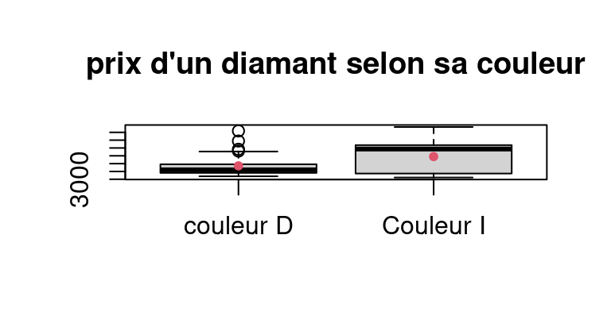

Interpréter ce graphique (3 commentaires attendus) :

1. Les positions médianes sont très différentes : beaucoup plus élevée pour les diamants de couleur I que D. Les diamants de couleurs I sont “en médiane” plus chers que ceux de couleur D.
2. La dispersion des prix est beaucoup plus importante pour I que pour D.
3. La répartition observée dans chaque échantillon et, particulièrement pour les diamants de couleur I, est dissymétrique.
4. A noter aussi quelques individus extrêmes dans l’échantillon des diamants de couleur D.

## Exercice 2 (12 pts)

### question 1 (10 pts)

Représenter sur l’intervalle $[-3,3]$ la fonction $f$ valant $x+1$ sur l’intervalle $[-1,0]$, $-x+1$ sur l’intervalle $[0,1]$ et 0 partout ailleurs (on utilisera la fonction pour tracer la fonction sur $[-3,-1]$ et sur $[1,3]$ et on tracera son graphe en rouge). Y ajouter en vert la densité d’une variable de loi ${\cal N}(0,1)$. Indiquer le titre “deux densités”, la légende “densité” en ordonnée et ajouter l’axe des ordonnées en noir (pas celui des abscisses). En d’autres termes, reproduire le graphique suivant :

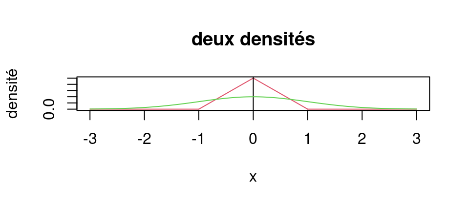

```r
curve(x+1,xlim=c(-3,3),from=-1,to=0, col=2,main="deux densités",ylab="densité")
# 4 points : 1,5 pour curve(x+1,) et 0.5 pour chaque option
curve(-x+1,from=0, to=1,add=T,col=2 ) # 2 points
abline(v=0) # 0.5 pt
segments(-3,0,-1,0,col=2) # 1 pt
segments(1,0,3,0,col=2) # 1 pt
curve(dnorm(x),col=3,add=T) # 1,5 pts
```

### question 2 (2 pts)

La fonction tracée en rouge est une densité de probabilité car c’est une fonction positive ($>=0$) sur $]-\infty,\infty[$ et d’intégrale sur son domaine valant 1.